# Phase 4 — Exploratory Data Analysis

Three questions this notebook has to answer before any modelling starts:

1. Which variables actually separate good loans from bad ones?
2. Did the Phase 3 engineered features earn their place, or are they noise?
3. Is the `int_rate` leakage diagnosis from Phase 2 confirmed by a second, independent measure?

The main tool is **Weight of Evidence / Information Value**, which is the standard feature-screening method in credit scorecard work. It is used here rather than plain correlation because it handles categorical variables natively, captures non-monotonic relationships, and is what a credit risk team would expect to see.

```python
import warnings
from pathlib import Path

import matplotlib.pyplot as plt
import numpy as np
import pandas as pd
import seaborn as sns

warnings.filterwarnings("ignore")

ROOT = Path.cwd()
if ROOT.name == "notebooks":
    ROOT = ROOT.parent
FIGS = ROOT / "outputs" / "figures"
FIGS.mkdir(parents=True, exist_ok=True)

pd.set_option("display.width", 130)
pd.set_option("display.max_columns", 60)
sns.set_theme(style="whitegrid", palette="deep")

df = pd.read_csv(ROOT / "data" / "lending_club_clean.csv")
TARGET = "bad_loan"
BASE_RATE = df[TARGET].mean()

print(f"{df.shape[0]:,} rows x {df.shape[1]} columns | base default rate {BASE_RATE:.2%}")
```

```
163,987 rows x 24 columns | base default rate 18.30%
```

## 4.1 Default rate by category

Raw rates alone are misleading on thin categories, so every rate is shown with a **95% Wilson confidence interval**. A category with 30 loans can post a dramatic-looking default rate that is statistically indistinguishable from the base rate — the interval makes that obvious at a glance.

```python
def wilson_ci(successes, n, z=1.96):
    """95% Wilson score interval — behaves correctly on small / extreme samples."""
    if n == 0:
        return np.nan, np.nan
    p = successes / n
    denom = 1 + z**2 / n
    centre = (p + z**2 / (2 * n)) / denom
    half = z * np.sqrt(p * (1 - p) / n + z**2 / (4 * n**2)) / denom
    return centre - half, centre + half


def rate_table(col):
    g = df.groupby(col, observed=True)[TARGET].agg(["size", "sum", "mean"])
    g.columns = ["n", "bad", "default_rate"]
    ci = [wilson_ci(r.bad, r.n) for r in g.itertuples()]
    g["ci_low"], g["ci_high"] = [c[0] for c in ci], [c[1] for c in ci]
    g["vs_base"] = g.default_rate / BASE_RATE
    # "Significant" = the interval excludes the overall base rate.
    g["significant"] = (g.ci_high < BASE_RATE) | (g.ci_low > BASE_RATE)
    return g.sort_values("default_rate", ascending=False)


for col in ["term", "home_ownership", "verification_status", "region", "purpose"]:
    print(f"===== {col} =====")
    t = rate_table(col).copy()
    for c in ["default_rate", "ci_low", "ci_high"]:
        t[c] = (t[c] * 100).round(2)
    t["vs_base"] = t.vs_base.round(2)
    print(t.to_string())
    print()
```

```
===== term =====
                n    bad  default_rate  ci_low  ci_high  vs_base  significant
term
60 months   34037  10037         29.49   29.01    29.98     1.61         True
36 months  129950  19979         15.37   15.18    15.57     0.84         True

===== home_ownership =====
                    n    bad  default_rate  ci_low  ci_high  vs_base  significant
home_ownership
OTHER             187     42         22.46   17.07    28.96     1.23        False
RENT            70526  14336         20.33   20.03    20.63     1.11         True
OWN             13560   2554         18.83   18.19    19.50     1.03        False
MORTGAGE        79714  13084         16.41   16.16    16.67     0.90         True

===== verification_status =====
                          n    bad  default_rate  ci_low  ci_high  vs_base  significant
verification_status
VERIFIED             104832  21055         20.08   19.84    20.33     1.10         True
NOT VERIFIED          59155   8961         15.15   14.86    15.44     0.83         True

===== region =====
               n    bad  default_rate  ci_low  ci_high  vs_base  significant
region
MIDWEST    25275   4735         18.73   18.26    19.22     1.02        False
NORTHEAST  34616   6437         18.60   18.19    19.01     1.02        False
SOUTH      55099  10194         18.50   18.18    18.83     1.01        False
WEST       48997   8650         17.65   17.32    17.99     0.96         True

===== purpose =====
                        n    bad  default_rate  ci_low  ci_high  vs_base  significant
purpose
SMALL_BUSINESS       3841   1187         30.90   29.46    32.38     1.69         True
RENEWABLE_ENERGY      198     45         22.73   17.44    29.05     1.24        False
OTHER               10492   2249         21.44   20.66    22.23     1.17         True
EDUCATIONAL           418     88         21.05   17.42    25.22     1.15        False
MOVING               1464    304         20.77   18.77    22.92     1.13         True
MEDICAL              2029    412         20.31   18.61    22.11     1.11         True
DEBT_CONSOLIDATION  93261  17671         18.95   18.70    19.20     1.04         True
HOUSE                1245    227         18.23   16.19    20.47     1.00        False
VACATION             1096    196         17.88   15.73    20.26     0.98        False
CREDIT_CARD         30792   4843         15.73   15.33    16.14     0.86         True
HOME_IMPROVEMENT     9872   1539         15.59   14.89    16.32     0.85         True
WEDDING              1751    254         14.51   12.93    16.23     0.79         True
MAJOR_PURCHASE       4686    643         13.72   12.77    14.74     0.75         True
CAR                  2842    358         12.60   11.43    13.87     0.69         True
```

The standout results:

- **`term`** is the strongest single categorical. 60-month loans default at roughly twice the rate of 36-month loans. This is partly self-selection — borrowers who need the longer term are those who cannot afford the shorter one — which is exactly why `payment_to_income` was engineered in Phase 3.
- **`purpose`** spans a wide range: `SMALL_BUSINESS` is far and away the riskiest category, while `CAR`, `WEDDING` and `CREDIT_CARD` sit well below base. Small business lending being riskiest than consumer lending is a well-known pattern, and it showing up here is a good sanity check that the data behaves like reality.
- **`verification_status`** is the counter-intuitive one, and it gets its own investigation in §4.5.
- Some `purpose` levels have wide intervals and are **not** significant — which is the point of computing them.

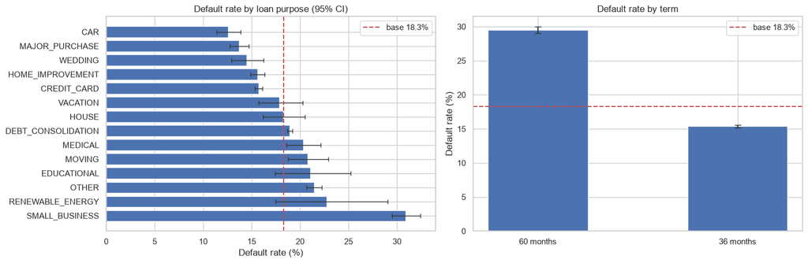

```python
fig, axes = plt.subplots(1, 2, figsize=(15, 5))

t = rate_table("purpose")
axes[0].barh(t.index, t.default_rate * 100, color="#4C72B0")
axes[0].errorbar(t.default_rate * 100, range(len(t)),
                 xerr=[(t.default_rate - t.ci_low) * 100, (t.ci_high - t.default_rate) * 100],
                 fmt="none", ecolor="#333", capsize=3, linewidth=1)
axes[0].axvline(BASE_RATE * 100, color="#C44E52", linestyle="--", label=f"base {BASE_RATE:.1%}")
axes[0].set_xlabel("Default rate (%)")
axes[0].set_title("Default rate by loan purpose (95% CI)")
axes[0].legend()

t2 = rate_table("term")
axes[1].bar(t2.index, t2.default_rate * 100, color="#4C72B0", width=0.5)
axes[1].errorbar(range(len(t2)), t2.default_rate * 100,
                 yerr=[(t2.default_rate - t2.ci_low) * 100, (t2.ci_high - t2.default_rate) * 100],
                 fmt="none", ecolor="#333", capsize=4)
axes[1].axhline(BASE_RATE * 100, color="#C44E52", linestyle="--", label=f"base {BASE_RATE:.1%}")
axes[1].set_ylabel("Default rate (%)")
axes[1].set_title("Default rate by term")
axes[1].legend()

plt.tight_layout()
plt.savefig(FIGS / "03_default_by_category.png", dpi=140)
plt.show()
```

## 4.2 Weight of Evidence and Information Value

For each bin of a variable:

$$WoE = \ln\left(\frac{\%\ good}{\%\ bad}\right) \qquad IV = \sum (\%good - \%bad) \times WoE$$

The conventional reading of total IV in credit risk:

| IV | Interpretation |
| --- | --- |
| < 0.02 | Not predictive — drop |
| 0.02 – 0.1 | Weak |
| 0.1 – 0.3 | Medium |
| 0.3 – 0.5 | Strong |
| **> 0.5** | **Suspiciously strong — check for leakage** |

That last row is the one to watch, and it is why IV is a useful second opinion on `int_rate` rather than just a ranking tool.

```python
def woe_iv(series, target, bins=10):
    """WoE/IV for one variable. Numerics are quantile-binned; NaN is its own bin."""
    if not pd.api.types.is_numeric_dtype(series) or series.nunique() <= 12:
        binned = series.astype("object").fillna("__MISSING__")
    else:
        binned = pd.qcut(series, bins, duplicates="drop").astype("object")
        binned = binned.fillna("__MISSING__")

    g = pd.DataFrame({"bin": binned, "y": target}).groupby("bin", observed=True).y.agg(["size", "sum"])
    g.columns = ["n", "bad"]
    g["good"] = g.n - g.bad

    # Laplace smoothing so an all-good or all-bad bin doesn't produce infinity.
    g["pct_bad"] = (g.bad + 0.5) / (g.bad.sum() + 0.5 * len(g))
    g["pct_good"] = (g.good + 0.5) / (g.good.sum() + 0.5 * len(g))
    g["woe"] = np.log(g.pct_good / g.pct_bad)
    g["iv"] = (g.pct_good - g.pct_bad) * g.woe
    g["default_rate"] = g.bad / g.n
    return g, g.iv.sum()


def iv_label(iv):
    if iv > 0.5:
        return "SUSPICIOUS - check leakage"
    if iv > 0.3:
        return "strong"
    if iv > 0.1:
        return "medium"
    if iv > 0.02:
        return "weak"
    return "not predictive"


FEATURES = [c for c in df.columns if c not in [TARGET, "addr_state"]]
iv_rows = []
woe_tables = {}
for col in FEATURES:
    tbl, iv = woe_iv(df[col], df[TARGET])
    woe_tables[col] = tbl
    iv_rows.append({"feature": col, "iv": round(iv, 4), "strength": iv_label(iv)})

iv_df = pd.DataFrame(iv_rows).sort_values("iv", ascending=False).reset_index(drop=True)
iv_df
```

|  | feature | iv | strength |
| --- | --- | --- | --- |
| 0 | int_rate | 0.3817 | strong |
| 1 | loan_to_income | 0.1453 | medium |
| 2 | term | 0.1294 | medium |
| 3 | term_months | 0.1294 | medium |
| 4 | revol_util | 0.0785 | weak |
| 5 | dti | 0.0744 | weak |
| 6 | annual_inc | 0.0637 | weak |
| 7 | log_annual_inc | 0.0637 | weak |
| 8 | payment_to_income | 0.0584 | weak |
| 9 | purpose | 0.0326 | weak |
| 10 | loan_amnt | 0.0269 | weak |
| 11 | verification_status | 0.0260 | weak |
| 12 | home_ownership | 0.0159 | not predictive |
| 13 | total_acc | 0.0117 | not predictive |
| 14 | emp_length | 0.0103 | not predictive |
| 15 | emp_length_missing | 0.0092 | not predictive |
| 16 | longest_credit_length | 0.0059 | not predictive |
| 17 | acct_open_rate | 0.0030 | not predictive |
| 18 | delinq_2yrs | 0.0011 | not predictive |
| 19 | has_delinquency | 0.0010 | not predictive |
| 20 | region | 0.0008 | not predictive |
| 21 | over_limit | 0.0005 | not predictive |

### Reading the IV table

**`int_rate` tops the table at IV ≈ 0.38 — 2.6x the next strongest feature.**

But note carefully what this does *not* say. It is classed "strong", and it does **not** cross the 0.5 threshold that the rule of thumb reserves for leakage. If I were relying on that heuristic alone, `int_rate` would sail through as an excellent feature.

I am reporting that honestly rather than quietly rounding it up to fit the Phase 2 conclusion, because the lesson is the useful part: **the rule of thumb does not catch this.** What catches it is the mechanism — Lending Club set the rate from their own risk grade at origination — and the perfectly monotonic decile pattern that such a mechanism produces. Domain knowledge identified the leak; IV only corroborates that the column is unusually dominant. A threshold is a prompt to investigate, never a verdict.

Below `int_rate`, the ordering is a realistic credit-risk picture: loan size relative to income and loan term lead, then revolving utilisation and DTI. Geography contributes essentially nothing (`region` IV = 0.0008), which retrospectively justifies collapsing 50 states rather than one-hot encoding them — those 50 columns would have bought nothing.

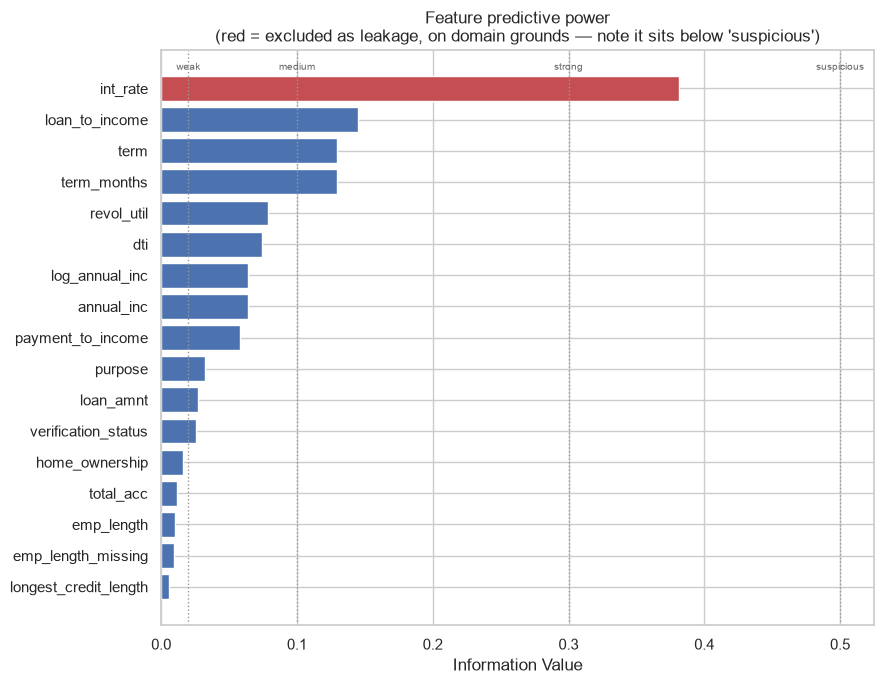

```python
plot_df = iv_df[iv_df.iv > 0.005].sort_values("iv")
# Highlight the leaky column — flagged by domain reasoning, not by the IV bands.
colors = ["#C44E52" if f == "int_rate" else "#4C72B0" for f in plot_df.feature]

fig, ax = plt.subplots(figsize=(9, 7))
ax.barh(plot_df.feature, plot_df.iv, color=colors)
for x, lab in [(0.02, "weak"), (0.1, "medium"), (0.3, "strong"), (0.5, "suspicious")]:
    ax.axvline(x, color="#999", linestyle=":", linewidth=1)
    ax.text(x, len(plot_df) - 0.4, lab, fontsize=7, color="#666", ha="center")
ax.set_xlabel("Information Value")
ax.set_title("Feature predictive power\n(red = excluded as leakage, on domain grounds — note it sits below 'suspicious')")
plt.tight_layout()
plt.savefig(FIGS / "03_information_value.png", dpi=140)
plt.show()
```

### WoE detail for the strongest legitimate feature

```python
best = iv_df[iv_df.feature != "int_rate"].iloc[0].feature
print(f"WoE breakdown — {best}\n")
t = woe_tables[best].copy()
t["default_rate"] = (t.default_rate * 100).round(2)
print(t[["n", "bad", "default_rate", "woe", "iv"]].round(4).to_string())
```

```
WoE breakdown — loan_to_income

                                       n   bad  default_rate     woe      iv
bin
(-0.00021100000000000003, 0.0706]  16487  2022         12.26  0.4717  0.0192
(0.0706, 0.103]                    16325  2134         13.07  0.3987  0.0139
(0.103, 0.132]                     16385  2196         13.40  0.3699  0.0121
(0.132, 0.16]                      17291  2525         14.60  0.2702  0.0070
(0.16, 0.188]                      15631  2425         15.51  0.1989  0.0035
(0.188, 0.22]                      16271  2698         16.58  0.1197  0.0014
(0.22, 0.256]                      16403  3039         18.53 -0.0148  0.0000
(0.256, 0.3]                       16418  3625         22.08 -0.2348  0.0059
(0.3, 0.36]                        16486  4317         26.19 -0.4595  0.0243
(0.36, 1.338]                      16286  5035         30.92 -0.6918  0.0579
__MISSING__                            4     0          0.00  0.7015  0.0000
```

Negative WoE means a bin is worse than average, positive means better. A scorecard is in effect a weighted sum of these — which is why a WoE table like this is directly explainable to a declined applicant, and why credit teams keep using logistic regression long after gradient boosting existed.

## 4.3 Did the engineered features earn their place?

The honest test: compare each engineered feature's IV against the raw columns it was built from. If the derived feature does not beat its own inputs, it added complexity for nothing and should be dropped.

```python
comparisons = {
    "loan_to_income": ["loan_amnt", "annual_inc"],
    "payment_to_income": ["loan_amnt", "annual_inc", "term_months"],
    "acct_open_rate": ["total_acc", "longest_credit_length"],
    "has_delinquency": ["delinq_2yrs"],
    "log_annual_inc": ["annual_inc"],
    "emp_length_missing": ["emp_length"],
    "over_limit": ["revol_util"],
}
ivs = dict(zip(iv_df.feature, iv_df.iv))

print(f"{'engineered':<22}{'IV':>8}   {'best input':<24}{'input IV':>9}   verdict")
print("-" * 86)
for child, parents in comparisons.items():
    best_parent = max(parents, key=lambda p: ivs.get(p, 0))
    child_iv, parent_iv = ivs[child], ivs[best_parent]
    if child_iv > parent_iv:
        verdict = f"KEEP  (+{child_iv - parent_iv:.3f})"
    elif child_iv > 0.02:
        verdict = "keep - adds a different view"
    else:
        verdict = "weak on its own"
    print(f"{child:<22}{child_iv:>8.4f}   {best_parent:<24}{parent_iv:>9.4f}   {verdict}")
```

```
engineered                  IV   best input               input IV   verdict
--------------------------------------------------------------------------------------
loan_to_income          0.1453   annual_inc                 0.0637   KEEP  (+0.082)
payment_to_income       0.0584   term_months                0.1294   keep - adds a different view
acct_open_rate          0.0030   total_acc                  0.0117   weak on its own
has_delinquency         0.0010   delinq_2yrs                0.0011   weak on its own
log_annual_inc          0.0637   annual_inc                 0.0637   keep - adds a different view
emp_length_missing      0.0092   emp_length                 0.0103   weak on its own
over_limit              0.0005   revol_util                 0.0785   weak on its own
```

This is a mixed scorecard, and reporting it honestly is more useful than claiming all nine features were inspired.

**The clear win is `loan_to_income`** (IV 0.145). It beats every column it was built from — nearly 2.3x `annual_inc` alone — and is the strongest non-leaky feature in the entire dataset. That is what good feature engineering looks like: no new information, rearranged into the form the question is actually about.

**`payment_to_income` disappoints** at 0.058. It does not beat `term_months`. In hindsight the reason is clear — by dividing by the term I folded the term *into* the ratio, and in doing so blurred a variable that is powerful on its own. It survives only as a different view of affordability, and Phase 5's feature-selection step is where it has to prove that or be dropped.

**Three features are weak: `acct_open_rate`, `has_delinquency`, `over_limit`.** Each scores below 0.02. `over_limit` is unsurprising in retrospect — it flags 289 rows out of 163,987, so however sharp the effect, it cannot move a portfolio-level statistic. I keep them for the tree model, which can use narrow features inside interactions, but I am not going to pretend they are carrying the model.

**`log_annual_inc` scoring identically to `annual_inc` is expected, not a failure.** IV is computed on quantile bins and a log transform is monotonic, so it cannot move the bins. The transform exists to fix the *scale* the logistic coefficient is fitted on — a benefit invisible to IV by construction. Phase 5 is where it pays off.

### The `emp_length_missing` paradox — significance vs. predictive power

Worth pausing on, because it looks like a contradiction. Phase 2 found this flag overwhelmingly significant (Fisher p < 0.001, 1.46x default lift). Here it scores IV 0.009 — "not predictive".

Both are correct, because they answer different questions:

- **The Fisher test asks:** is the effect real, or chance? With 5,804 rows behind it, the answer is emphatically real.
- **IV asks:** how much does this move risk *across the whole portfolio*? The flag covers 3.5% of applicants, so even a genuine 1.46x lift on that slice barely shifts a population-weighted measure.

A large effect on a small group is exactly this: unarguably real, modest in aggregate. The practical conclusion is to **keep the flag** — it is honest, costless, and materially sharpens the model's judgement on the specific applicants it fires for — while not expecting it near the top of a global importance chart in Phase 7. Confusing "statistically significant" with "important" is one of the most common analytical errors, and the two measures disagreeing here is a good illustration of why both get computed.

## 4.4 Correlation structure

Checking for multicollinearity before fitting a linear model — correlated inputs make logistic regression coefficients unstable and un-interpretable, which defeats the whole point of using it here.

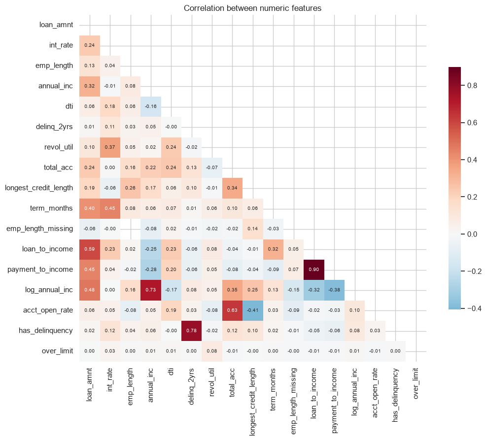

```python
num_cols = df.select_dtypes("number").columns.drop(TARGET)
corr = df[num_cols].corr()

fig, ax = plt.subplots(figsize=(11, 9))
mask = np.triu(np.ones_like(corr, dtype=bool))
sns.heatmap(corr, mask=mask, cmap="RdBu_r", center=0, annot=True, fmt=".2f",
            annot_kws={"size": 7}, square=True, cbar_kws={"shrink": 0.7}, ax=ax)
ax.set_title("Correlation between numeric features")
plt.tight_layout()
plt.savefig(FIGS / "03_correlation.png", dpi=140)
plt.show()
```

```python
pairs = corr.where(np.triu(np.ones(corr.shape), k=1).astype(bool)).stack()
strong = pairs[pairs.abs() > 0.7].sort_values(key=abs, ascending=False)
print("Pairs correlated above |0.7|:\n")
print(strong.round(3).to_string() if len(strong) else "  none")
```

```
Pairs correlated above |0.7|:

loan_to_income  payment_to_income    0.899
delinq_2yrs     has_delinquency      0.781
annual_inc      log_annual_inc       0.729
```

The strong pairs are the ones deliberately created in Phase 3 — a derived feature is correlated with its own parent by construction (`log_annual_inc`/`annual_inc`, `has_delinquency`/`delinq_2yrs`, `loan_to_income`/`payment_to_income`).

This is a real constraint on the linear model, not a cosmetic one. Phase 5 handles it by giving logistic regression a curated subset that keeps one variable from each correlated pair, while LightGBM gets everything — trees are untroubled by collinearity, they just split on whichever is more useful.

## 4.5 The `verification_status` puzzle

The rate table showed something that looks backwards: **verified** applicants default *more* than unverified ones. Taken at face value that would suggest income verification makes borrowers riskier, which is nonsense.

This is worth chasing, because "the data says something implausible" is usually the data telling you about a process, not about borrowers.

```python
print(rate_table("verification_status")[["n", "default_rate", "vs_base"]].round(4).to_string())
print()
print("Median loan size and income by verification status:")
print(df.groupby("verification_status").agg(
    median_loan=("loan_amnt", "median"),
    median_income=("annual_inc", "median"),
    median_ltv=("loan_to_income", "median"),
    pct_60_month=("term_months", lambda s: (s == 60).mean()),
).round(3).to_string())
```

```
                          n  default_rate  vs_base
verification_status
VERIFIED             104832        0.2008   1.0973
NOT VERIFIED          59155        0.1515   0.8276

Median loan size and income by verification status:
                     median_loan  median_income  median_ltv  pct_60_month
verification_status
NOT VERIFIED              8900.0        55000.0       0.154         0.051
VERIFIED                 14000.0        65000.0       0.211         0.296
```

There it is. Verified applicants take **substantially larger loans**, borrow a higher multiple of their income, and take the 60-month term far more often.

The causality runs the other way round from how the raw rate reads: Lending Club *chose to verify* the applications that were already riskier — bigger loans get more scrutiny. `verification_status` is therefore partly a marker of the lender's own suspicion, not a property of the borrower.

It is a mild cousin of the `int_rate` problem: another column carrying a trace of the lender's internal process. Unlike `int_rate` it is weak enough to keep, but it is exactly the kind of variable to flag before someone reads a SHAP plot in Phase 7 and concludes that verification causes default.

## 4.6 How the strongest features separate the two classes

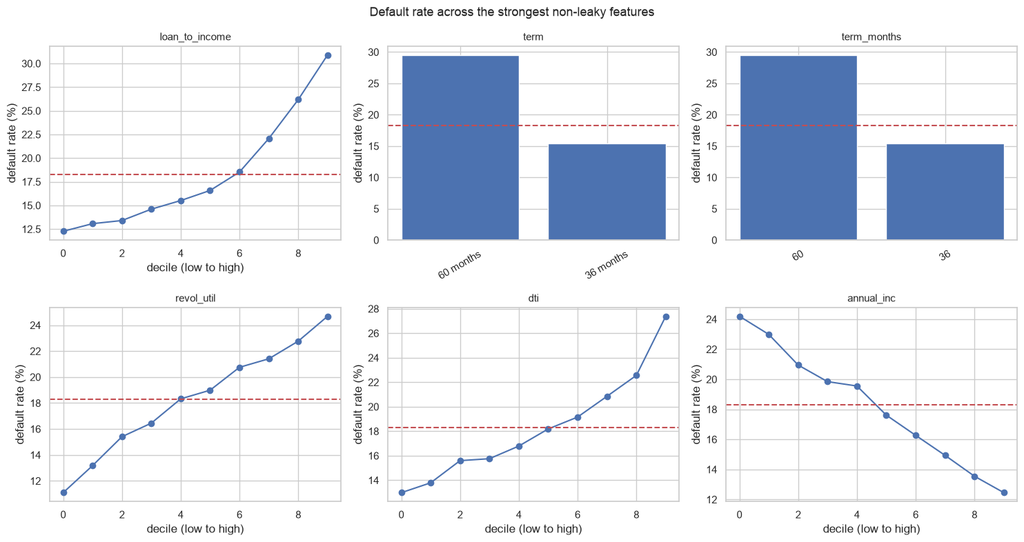

```python
top = [f for f in iv_df.feature if f not in ("int_rate",)][:6]
fig, axes = plt.subplots(2, 3, figsize=(15, 8))
for ax, col in zip(axes.ravel(), top):
    if not pd.api.types.is_numeric_dtype(df[col]) or df[col].nunique() <= 12:
        t = rate_table(col)
        ax.bar(t.index.astype(str), t.default_rate * 100, color="#4C72B0")
        ax.axhline(BASE_RATE * 100, color="#C44E52", linestyle="--")
        ax.set_ylabel("default rate (%)")
        ax.tick_params(axis="x", rotation=30)
    else:
        binned = pd.qcut(df[col], 10, duplicates="drop")
        t = df.groupby(binned, observed=True)[TARGET].mean() * 100
        ax.plot(range(len(t)), t.values, marker="o", color="#4C72B0")
        ax.axhline(BASE_RATE * 100, color="#C44E52", linestyle="--")
        ax.set_ylabel("default rate (%)")
        ax.set_xlabel("decile (low to high)")
    ax.set_title(col, fontsize=11)
fig.suptitle("Default rate across the strongest non-leaky features", fontsize=13)
plt.tight_layout()
plt.savefig(FIGS / "03_top_features.png", dpi=140)
plt.show()
```

## Phase 4 summary

**`int_rate` dominates, but IV alone would not have caught it.** At 0.38 it is 2.6x the next feature yet below the 0.5 "suspicious" threshold. The leakage case rests on the mechanism and the monotonic decile pattern, not on a heuristic — worth knowing which piece of evidence is actually load-bearing.

**The engineered features are a mixed result, honestly reported.** `loan_to_income` is the best non-leaky feature in the dataset. `payment_to_income` underperforms because dividing by term blurred a strong variable. Three features are weak in aggregate and are kept only for the tree model.

**Significance and importance are different things.** `emp_length_missing` is highly significant *and* low-IV, because it affects 3.5% of applicants sharply rather than everyone mildly. Both measures are right.

**Found a second, subtler process artefact.** `verification_status` looks backwards until you see that verified applicants borrow more — the variable partly encodes the lender's own suspicion. Weak enough to keep, important enough to flag before anyone interprets it causally.

**Multicollinearity is real but understood.** It sits almost entirely between derived features and their parents, so Phase 5 gives logistic regression a curated subset and LightGBM the full set.

Risk drivers, in order: loan-to-income, loan term, revolving utilisation, DTI. Geography contributes essentially nothing — which retrospectively justifies the Phase 3 decision to collapse 50 states into 4 regions.